# Project Foundations for Data Science: FoodHub Data Analysis

**Marks: 40**

### Context

The number of restaurants in New York is increasing day by day. Lots of students and busy professionals rely on those restaurants due to their hectic lifestyles. Online food delivery service is a great option for them. It provides them with good food from their favorite restaurants. A food aggregator company FoodHub offers access to multiple restaurants through a single smartphone app.

The app allows the restaurants to receive a direct online order from a customer. The app assigns a delivery person from the company to pick up the order after it is confirmed by the restaurant. The delivery person then uses the map to reach the restaurant and waits for the food package. Once the food package is handed over to the delivery person, he/she confirms the pick-up in the app and travels to the customer's location to deliver the food. The delivery person confirms the drop-off in the app after delivering the food package to the customer. The customer can rate the order in the app. The food aggregator earns money by collecting a fixed margin of the delivery order from the restaurants.

### Objective

The food aggregator company has stored the data of the different orders made by the registered customers in their online portal. They want to analyze the data to get a fair idea about the demand of different restaurants which will help them in enhancing their customer experience. Suppose you are hired as a Data Scientist in this company and the Data Science team has shared some of the key questions that need to be answered. Perform the data analysis to find answers to these questions that will help the company to improve the business.

### Data Description

The data contains the different data related to a food order. The detailed data dictionary is given below.

### Data Dictionary

- order_id: Unique ID of the order
- customer_id: ID of the customer who ordered the food
- restaurant_name: Name of the restaurant
- cuisine_type: Cuisine ordered by the customer
- cost: Cost of the order
- day_of_the_week: Indicates whether the order is placed on a weekday or weekend (The weekday is from Monday to Friday and the weekend is Saturday and Sunday)
- rating: Rating given by the customer out of 5
- food_preparation_time: Time (in minutes) taken by the restaurant to prepare the food. This is calculated by taking the difference between the timestamps of the restaurant's order confirmation and the delivery person's pick-up confirmation.
- delivery_time: Time (in minutes) taken by the delivery person to deliver the food package. This is calculated by taking the difference between the timestamps of the delivery person's pick-up confirmation and drop-off information

### Let us start by importing the required libraries

```python
# import libraries for data manipulation
import numpy as np
import pandas as pd

# import libraries for data visualization
import matplotlib.pyplot as plt
import seaborn as sns
```

### Understanding the structure of the data

```python
# uncomment and run the following lines for Google Colab
# from google.colab import drive
# drive.mount('/content/drive')
```

```python
# read the data
df = pd.read_csv('foodhub_order.csv')
# returns the first 5 rows
df.head()
```

|  | order_id | customer_id | restaurant_name | cuisine_type | cost_of_the_order | day_of_the_week | rating | food_preparation_time | delivery_time |
| --- | --- | --- | --- | --- | --- | --- | --- | --- | --- |
| 0 | 1477147 | 337525 | Hangawi | Korean | 30.75 | Weekend | Not given | 25 | 20 |
| 1 | 1477685 | 358141 | Blue Ribbon Sushi Izakaya | Japanese | 12.08 | Weekend | Not given | 25 | 23 |
| 2 | 1477070 | 66393 | Cafe Habana | Mexican | 12.23 | Weekday | 5 | 23 | 28 |
| 3 | 1477334 | 106968 | Blue Ribbon Fried Chicken | American | 29.20 | Weekend | 3 | 25 | 15 |
| 4 | 1478249 | 76942 | Dirty Bird to Go | American | 11.59 | Weekday | 4 | 25 | 24 |

#### Observations:

The DataFrame has 9 columns as mentioned in the Data Dictionary. Data in each row corresponds to the order placed by a customer.

### **Question 1:** How many rows and columns are present in the data?

```python
# Write your code here

#Here I print the value of the columns and rows extracted from the .shape() attribute
print("The data set has",df.shape[0],"rows and", df.shape[1], "columns.")
```

```
The data set has 1898 rows and 9 columns.
```

#### Observations:

The DataFrame has 1898 rows, is not a very big data set, but the information it contains will be used to the fullest extent possible.

### **Question 2:** What are the datatypes of the different columns in the dataset? (The info() function can be used)

```python
# Use info() to print a concise summary of the DataFrame
df.info()
```

```
<class 'pandas.core.frame.DataFrame'>
RangeIndex: 1898 entries, 0 to 1897
Data columns (total 9 columns):
 #   Column                 Non-Null Count  Dtype
---  ------                 --------------  -----
 0   order_id               1898 non-null   int64
 1   customer_id            1898 non-null   int64
 2   restaurant_name        1898 non-null   object
 3   cuisine_type           1898 non-null   object
 4   cost_of_the_order      1898 non-null   float64
 5   day_of_the_week        1898 non-null   object
 6   rating                 1898 non-null   object
 7   food_preparation_time  1898 non-null   int64
 8   delivery_time          1898 non-null   int64
dtypes: float64(1), int64(4), object(4)
memory usage: 133.6+ KB
```

#### Observations:

We obtain that 5 of the nine columns correspond to numbers, with 'order_id', 'customer_id', 'food_preparation_time' and 'delivery_time' as integers while 'cost_of_the_order' is a float.

The rest of the variables correspond to objects, so we can think that they are names of some kind.

### **Question 3:** Are there any missing values in the data? If yes, treat them using an appropriate method

```python
# Write your code here

#Missing values contains the total number of missing values per column
#We get these using .isnull().sum()
missing_values = df.isnull().sum()

#Print the values
print(missing_values)
```

```
order_id                 0
customer_id              0
restaurant_name          0
cuisine_type             0
cost_of_the_order        0
day_of_the_week          0
rating                   0
food_preparation_time    0
delivery_time            0
dtype: int64
```

#### Observations:

There are no missing values.

### **Question 4:** Check the statistical summary of the data. What is the minimum, average, and maximum time it takes for food to be prepared once an order is placed?

```python
# Write your code here

#We get the statistical summary using .describe()
df.describe()
```

|  | order_id | customer_id | cost_of_the_order | food_preparation_time | delivery_time |
| --- | --- | --- | --- | --- | --- |
| count | 1.898000e+03 | 1898.000000 | 1898.000000 | 1898.000000 | 1898.000000 |
| mean | 1.477496e+06 | 171168.478398 | 16.498851 | 27.371970 | 24.161749 |
| std | 5.480497e+02 | 113698.139743 | 7.483812 | 4.632481 | 4.972637 |
| min | 1.476547e+06 | 1311.000000 | 4.470000 | 20.000000 | 15.000000 |
| 25% | 1.477021e+06 | 77787.750000 | 12.080000 | 23.000000 | 20.000000 |
| 50% | 1.477496e+06 | 128600.000000 | 14.140000 | 27.000000 | 25.000000 |
| 75% | 1.477970e+06 | 270525.000000 | 22.297500 | 31.000000 | 28.000000 |
| max | 1.478444e+06 | 405334.000000 | 35.410000 | 35.000000 | 33.000000 |

#### Observations:

The minimum, average, and maximum time it takes for food to be prepared once an order is placed are:

minumim: 20 min avergae: 27.37 min maximum: 35 min

It's interesting to see that the range of the prices is 30.94 dollars and that the delivery time corresponds to the standar fast food delivery time that we know from pop culture, being the maximum time just 3 minutes above the half an hour.

### **Question 5:** How many orders are not rated?

```python
# Write the code here

#Using .value_counts() on the 'rating' column we can get this
not_rated = df['rating'].value_counts()

not_rated
```

```
rating
Not given    736
5            588
4            386
3            188
Name: count, dtype: int64
```

#### Observations:

736 out of the 1898 orders are not rated. It's worth mentioning that there are no 0, 1 and 2 star ratings.

### Exploratory Data Analysis (EDA)

### **Question 6:** Explore all the variables and provide observations on their distributions. (Generally, histograms, boxplots, countplots, etc. are used for univariate exploration)

#### Starrting with Order ID, CustomerID, Restauant name and Cuisine type

```python
# Write the code here

#Order ID
number_unique_orders= df['order_id'].nunique()
print("The numer of unique orders is:", number_unique_orders)

#customer ID
number_unique_ids = df['customer_id'].nunique()
print("The numer of unique customers ids is:", number_unique_ids)

#Restaurant Name
number_unique_restaurants = df['restaurant_name'].nunique()
print("The numer of unique restaurants is:", number_unique_restaurants)

#Cuisine type
number_unique_cuisine = df['cuisine_type'].nunique()
print("The numer of unique cuisine types is:", number_unique_cuisine)
```

```
The numer of unique orders is: 1898
The numer of unique customers ids is: 1200
The numer of unique restaurants is: 178
The numer of unique cuisine types is: 14
```

### Cusine type

With a countplot we can visualize the popularity of the cuisine types ordered.

```
[Text(0.5, 1.0, 'Cuisine type vs. Count')]
```

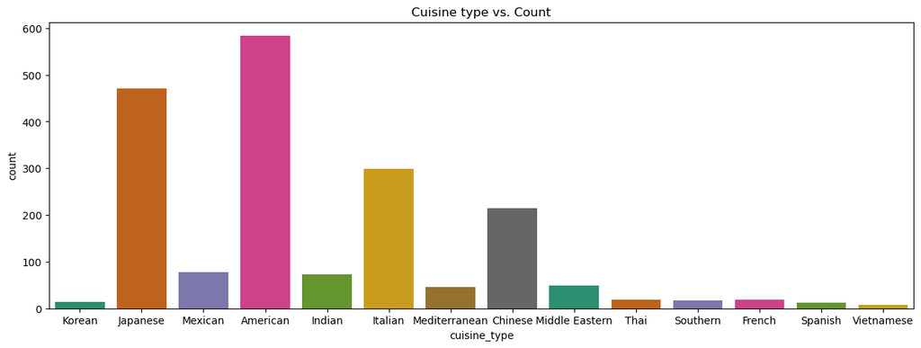

```python
plt.figure(figsize = (15,5))
sns.countplot(data = df, x = 'cuisine_type', palette="Dark2").set(title='Cuisine type vs. Count')
```

From this plot we observe that there's a big gap between the four most popular cuisine types and the rest, being the Mexican and Indian the closest ones, but still far from the American cuisine.

### Cost of order

For the cost of the order, a boxplot and a histogram could give us a view of how these values behave.

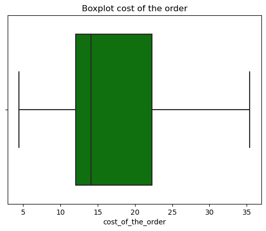

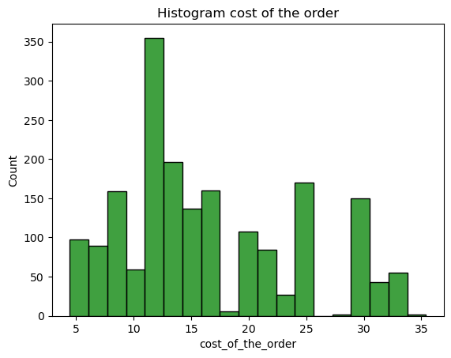

```python
#Boxplot
sns.boxplot(data=df,x='cost_of_the_order', color='green').set(title='Boxplot cost of the order')
plt.show()

#Histogram
sns.histplot(data=df,x='cost_of_the_order', color='green').set(title='Histogram cost of the order')
plt.show()
```

#### Day of the week

For the days of the week, a bar graph could give show us the representation of the orders during weekends and weekdays.

```
[Text(0.5, 1.0, 'Bar graph orders during weekdays and weekends')]
```

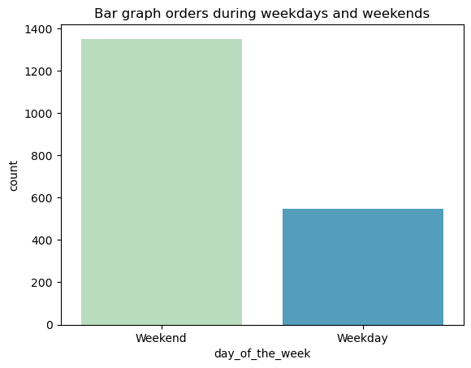

```python
#Bar graph
sns.countplot(data = df, x = 'day_of_the_week', palette='GnBu').set(title='Bar graph orders during weekdays and weekends')
```

From this graph, we now know that the number of orders during the weekend is more than double of the orders that take place during weekdays.

#### Rating

Repeating the graph for the ratings, we look for the scores that the customers give to the service provided.

```
[Text(0.5, 1.0, 'Bar graph of the ratings')]
```

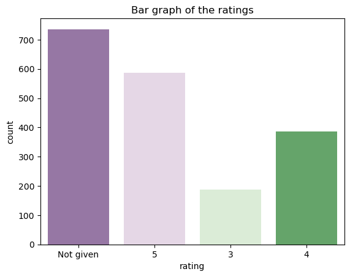

```python
#Bar graph
sns.countplot(data = df, x = 'rating', palette='PRGn').set(title='Bar graph of the ratings')
```

#### Food Preparation time

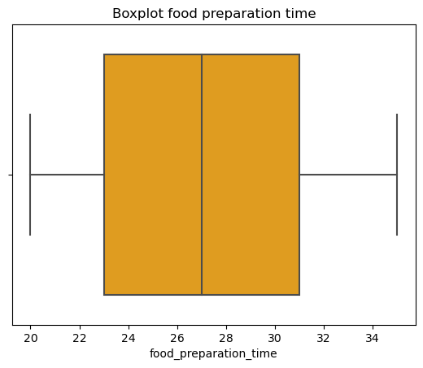

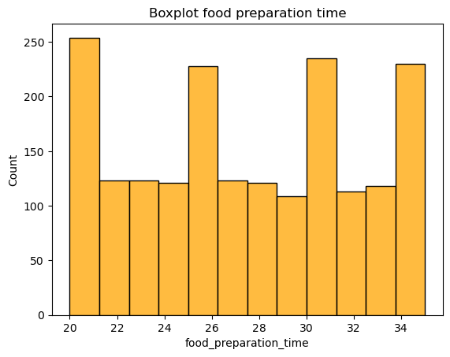

```python
#Box plot
sns.boxplot(data=df,x='food_preparation_time', color='orange').set(title='Boxplot food preparation time')
plt.show()

#Histogram
sns.histplot(data=df,x='food_preparation_time', color='orange').set(title='Boxplot food preparation time')
plt.show()
```

The histogram and the box plot show that there is not a clear tendecy in terms of the preparation time, having a significant number of orders that take around 20, 25, 31 and 35 minutes.

#### Delivery time

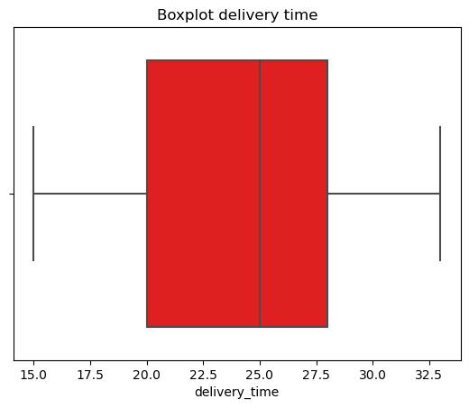

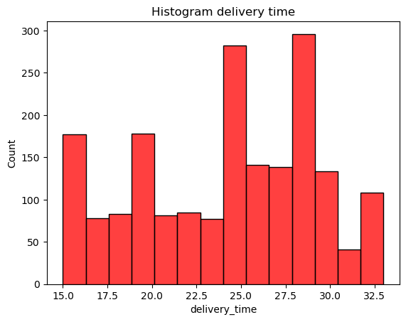

```python
#Box plot
sns.boxplot(data=df,x='delivery_time',  color='red').set(title='Boxplot delivery time')
plt.show()

#Histogram
sns.histplot(data=df,x='delivery_time', color='red').set(title='Histogram delivery time')
plt.show()
```

We can see that the delivery times gravitate more around the 25-30 minutes, with an interesting amount of deliveries that only take 15 minutes. As a hipothesis, this might be because of the proximity between the restaurants and the adresses where the ordes are delivered.

### **Question 7**: Which are the top 5 restaurants in terms of the number of orders received?

```python
# Write the code here
# We get top 5 restaurants with highest number of orders using .value_counts() on the
#column 'restaurant_names'
df['restaurant_name'].value_counts().head(10)
```

```
restaurant_name
Shake Shack                      219
The Meatball Shop                132
Blue Ribbon Sushi                119
Blue Ribbon Fried Chicken         96
Parm                              68
RedFarm Broadway                  59
RedFarm Hudson                    55
TAO                               49
Han Dynasty                       46
Blue Ribbon Sushi Bar & Grill     44
Name: count, dtype: int64
```

```python
#Now we look for the type of cuisine that they sell
type_of_cuisine_top_5  = df['restaurant_name'].value_counts().head(5).index.tolist()

#Empty list where we'll store the types of cuisine
corresponding_values = []

# Iterate through the list of values to find the type of cuisine
for value in type_of_cuisine_top_5:
    corresponding_value = df.loc[df['restaurant_name'] == value, 'cuisine_type'].values
    if len(corresponding_value) > 0:
        corresponding_values.append(corresponding_value[0])
    else:
        # Handle the case where a value is not found
        corresponding_values.append(None)

print("The types of cuisine of the top 5 restaurants in terms of the number of orders recived are::", corresponding_values)
```

```
The types of cuisine of the top 5 restaurants in terms of the number of orders recived are:: ['American', 'Italian', 'Japanese', 'American', 'Italian']
```

#### Observations:

The top 5 restaurants in termos of orders recived are: Shake Shack, The Meatball Shop, Blue Ribbon Sushi, Blue Ribbon Fried Chicken and Parm, each corresponds to 'American', 'Italian', 'Japanese', 'American' and 'Italian'type of cuisine respectively.

### **Question 8**: Which is the most popular cuisine on weekends?

```python
# Write the code here
# Get most popular cuisine on weekends
weekend_orders = df[df['day_of_the_week'] == 'Weekend']
popular_cuisine = weekend_orders['cuisine_type'].value_counts().idxmax()

print("The most popular type of food during weekends is:", popular_cuisine)
```

```
The most popular type of food during weekends is: American
```

```python
weekend_orders['cuisine_type'].value_counts()
```

```
cuisine_type
American          415
Japanese          335
Italian           207
Chinese           163
Mexican            53
Indian             49
Mediterranean      32
Middle Eastern     32
Thai               15
French             13
Korean             11
Southern           11
Spanish            11
Vietnamese          4
Name: count, dtype: int64
```

#### Observations:

The tree most popular types of cusine during the weekends are: American, Japanese and Italian. The least favorite are: Vietnamese, Spanish and Southern.

### **Question 9**: What percentage of the orders cost more than 20 dollars?

```python
#We get the orders that cost mre than $20
expensive_orders = df[df['cost_of_the_order'] > 20]

# Calculate the percentage of expensive orders
percentage_expensive = (len(expensive_orders) / len(df)) * 100

#We print the number of orders along with thw percentage
print("The number of ordes that cost more than $20 is:", len(expensive_orders),", which corresponds to the:", percentage_expensive, "%")
```

```
The number of ordes that cost more than $20 is: 555 , which corresponds to the: 29.24130663856691 %
```

#### Observations:

Considering the maximum value of an order is 35.41 dollars, we can start to see that the cost of the orders usually stays below $20.

### **Question 10**: What is the mean order delivery time?

```python
# Write the code here

# We get the mean delivery time
mean_delivery_time = df['delivery_time'].mean()

#We print the value with the message
print('The mean delivery time is:', mean_delivery_time, 'minutes')
```

```
The mean delivery time is: 24.161749209694417 minutes
```

#### Observations:

The mean delivery time is relativley fast and just past 9 minutes from the minimum time of delivery, which we know is 15 minutes.

### **Question 11:** The company has decided to give 20% discount vouchers to the top 3 most frequent customers. Find the IDs of these customers and the number of orders they placed

```python
# Write the code here
# To get the ids of the top 3 mos frequest users we use value_counts().head(3)
#on the column çustomer_id', but we use .head(10) to have a wider view
df['customer_id'].value_counts().head(10)
```

```
customer_id
52832     13
47440     10
83287      9
250494     8
259341     7
82041      7
65009      7
276192     7
97079      6
97991      6
Name: count, dtype: int64
```

#### Observations:

Looking at the number of oders between the most frequent user and the tenth, it's interesting to see that is more than double, while the diference between the fisrt and third is just 4 orders.

### **Question 12**: Perform a multivariate analysis to explore relationships between the important variables in the dataset. (It is a good idea to explore relations between numerical variables as well as relations between numerical and categorical variables)

For the multivariate analysis, we can start with a sns boxplot to see the relationship between the cost of the orders and the type of the cuisine

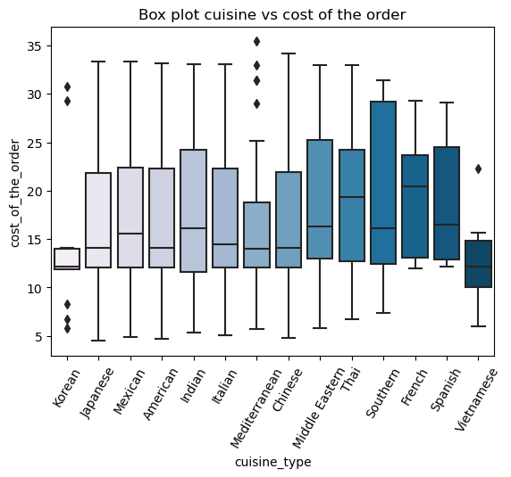

```python
# Write the code here
# Relationship between cost of the order and cuisine type

sns.boxplot(x = "cuisine_type", y = "cost_of_the_order", data = df, palette = 'PuBu').set(title='Box plot cuisine vs cost of the order')
#Rotate the labels
plt.xticks(rotation = 60)
plt.show()
```

With this plot we get that the cheapest cuisines are Kprean and Vietnamesse, with some outliers, but the graph shows that comprered to the Thai or French, the average prices are lower.

Moving to the relationship between the cuisine and the time it takes to be prepared and delivered, we have the next plots

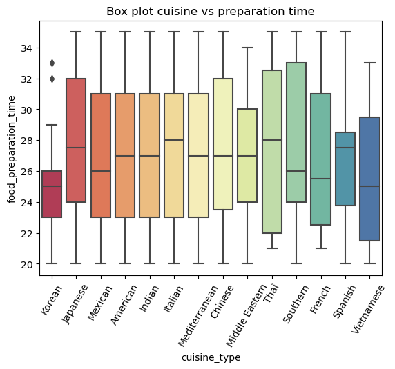

```python
# Write the code here
# Relationship between food preparation time and cuisine type

sns.boxplot(x = "cuisine_type", y = "food_preparation_time", data = df, palette = 'Spectral').set(title='Box plot cuisine vs preparation time')
plt.xticks(rotation = 60)
plt.show()
```

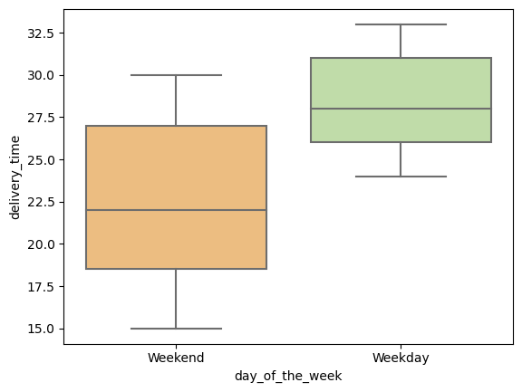

```python
#For the day of the Week vs Delivery time, we have a boxplot
sns.boxplot(x = "day_of_the_week", y = "delivery_time", data = df, palette = 'Spectral')
plt.show()
```

For the rating variable relation with the delivery time, food preparation time and cost of the orders, we have the next plots.

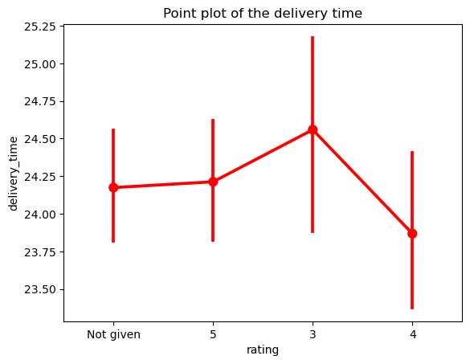

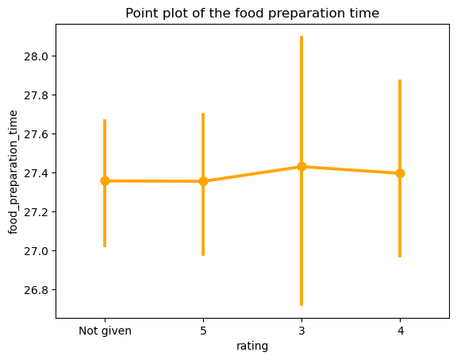

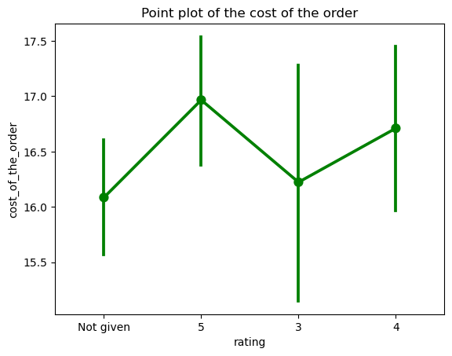

```python
# Relationship between rating and delivery time
sns.pointplot(x = 'rating', y = 'delivery_time', data = df, color='red').set(title='Point plot of the delivery time')
plt.show()

# Relationship between rating and food preparation time
sns.pointplot(x = 'rating', y = 'food_preparation_time', data = df, color='orange').set(title='Point plot of the food preparation time')
plt.show()

# Relationship between rating and cost of the order
sns.pointplot(x = 'rating', y = 'cost_of_the_order', data = df, color='green').set(title='Point plot of the cost of the order')
plt.show()
```

To see the relationship among the different variables, we use a heatmap.

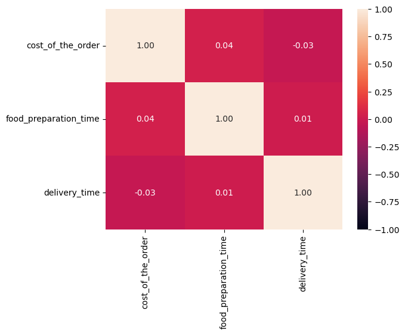

```python
# Plot the heatmap
col_list = ['cost_of_the_order', 'food_preparation_time', 'delivery_time']
sns.heatmap(df[col_list].corr(), annot=True, vmin=-1, vmax=1, fmt=".2f", cmap="rocket")
plt.show()
```

### **Question 13:** The company wants to provide a promotional offer in the advertisement of the restaurants. The condition to get the offer is that the restaurants must have a rating count of more than 50 and the average rating should be greater than 4. Find the restaurants fulfilling the criteria to get the promotional offer

```python
# Filter the rated restaurants
df_rated = df[df['rating'] != 'Not given'].copy()
df_rated['rating'] = df_rated['rating'].astype('int')
```

```python
# Filter to include only restaurants with more than 50 ratings
restaurant_counts = df_rated['restaurant_name'].value_counts()
popular_restaurants = restaurant_counts[restaurant_counts > 50].index

# Filter the DataFrame to include only orders from popular restaurants
popular_restaurants_data = df_rated[df_rated['restaurant_name'].isin(popular_restaurants)]

# Group the data by restaurant and calculate the mean rating for each restaurant
average_ratings = popular_restaurants_data.groupby('restaurant_name')['rating'].mean()

# Sort the restaurants by average rating greater than 4
top_restaurants = average_ratings[average_ratings > 4]

#print("Restaurants with an average rating > 3 and more than 2 orders made:")
print(top_restaurants)
```

```
restaurant_name
Blue Ribbon Fried Chicken    4.328125
Blue Ribbon Sushi            4.219178
Shake Shack                  4.278195
The Meatball Shop            4.511905
Name: rating, dtype: float64
```

#### Observations:

The restaurants that fulfill the criteria are: Blue Ribbon Fried Chicken, Blue Ribbon Sushi, Shake Shack and The Meatball Shop. Interesting to see that only four restarurants have both, more than 50 reviews and average rating greatter than four.

### **Question 14:** The company charges the restaurant 25% on the orders having cost greater than 20 dollars and 15% on the orders having cost greater than 5 dollars. Find the net revenue generated by the company across all orders

```python
#Function to determine the correspending revenue
def calculate_net_revenue(price):
    if price > 20:
        return price * 0.25  # 25% charge
    elif price > 5:
        return price * 0.15  # 15% charge
    else:
        return price * 0  # No charge

# Apply the function to calculate net revenue for each order
df['NetRevenue'] = df['cost_of_the_order'].apply(calculate_net_revenue)

# Calculate the total net revenue
total_net_revenue = df['NetRevenue'].sum()

print("Total Net Revenue:", total_net_revenue)
```

```
Total Net Revenue: 6166.303
```

```python
#Here we calculate the percentage of the revenue that goes to the company

#Total gross income
total_gross_revenue = df['cost_of_the_order'].sum()

#Percentage that the company keeps
percentage_of_revenue = (total_net_revenue / total_gross_revenue) * 100

print("Percentage of Total Revenue:", percentage_of_revenue, "%")
```

```
Percentage of Total Revenue: 19.691325065895317 %
```

#### Observations:

The company keeps 19.69% of all the income generated.

### **Question 15:** The company wants to analyze the total time required to deliver the food. What percentage of orders take more than 60 minutes to get delivered from the time the order is placed? (The food has to be prepared and then delivered)

```python
# Write the code here

# New column that sores the total time an order takes to get to the customer
df['total_time'] = df['food_preparation_time'] + df['delivery_time']


#Here we calculate the percentage of orders that take more than 60 minutes
percentage_more_than_60 = (len(df[df['total_time'] > 60]) / len(df)) * 100


print("Percentage of orders that take morw than 60 minutes:", percentage_more_than_60, "%")
```

```
Percentage of orders that take morw than 60 minutes: 10.537407797681771 %
```

#### Observations:

The porcentage is quite small, but something to take into consideration for the decisions moving on.

### **Question 16:** The company wants to analyze the delivery time of the orders on weekdays and weekends. How does the mean delivery time vary during weekdays and weekends?

```python
# Write the code here

# The mean delivery time on weekdays and weekends is calculated like this:
mean_delivery_time_by_day = df.groupby('day_of_the_week')['delivery_time'].mean()

#And then printed
print(mean_delivery_time_by_day)
```

```
day_of_the_week
Weekday    28.340037
Weekend    22.470022
Name: delivery_time, dtype: float64
```

#### Observations:

From the results we get that the mean delivery time on weekdays is around 28 minutes and the mean delivery time on weekends is around 22 minutes. This is interesting considering that the number of orders during the weekends is higher. This might be because of the traffic during the weekdays in comparison to the traffic during the weekends.

### Conclusion and Recommendations

### **Question 17:** What are your conclusions from the analysis? What recommendations would you like to share to help improve the business? (You can use cuisine type and feedback ratings to drive your business recommendations)

### Conclusions:

- American food is the most popular, followed by Japanese and Italian.
- Most users do not rate the service.
- The delivery times are shorter during weekends even though more orders are made.
- Of the 1898 orders filled by 178 restaurants, only three restaurants had more than 100 orders.
- The company keeps 19.69% of all the income generated.

### Recommendations:

- Due to the large number of users who do not qualify to the service, it is recommended to put incentives such as small discounts or coupons so that in the future we can make a more exhaustive analysis and further refine the measures to be taken to improve the business and the user experience.
- Due to longer delivery times on weekdays, it is recommended to promote restaurants that are attractive in price and preparation time, such as Korean and Vietnamese food, which are, according to the data, quick to prepare and low in cost.
- It is proposed to make agreements with the 4 most requested restaurants to obtain the latest dishes before other services or exclusive promotions, as these have proven to be the pillars of the income generated and customer reviews support them.